# Forecasting wildfire risk in Northern California

Teresa Chang & Tiffany Luo

December 8, 2022

## CA Wildfire Prediction with Google Maps Video Link: https://youtu.be/7oWQHZ53C1A

## 0. Setup

## 1. Motivation

Given those high numbers of loss of damages, we were thinking what if we can predict the risk level of wildfire to let people avoid the area or move/protect their properties before the fires happen. Therefore,we hope to partner with Google Maps (the map app that has the largest share of users in the map app market) to add a layer of wildfire prediction to the app. Basically, this app has two functions, alert, and route planning. For alert, when people use google maps, we want to inform them about the potential wildfire risk of their destinations by date. For route planning, we hope Google can integrate our wildfire prediction feature to their route planning algorithm.

In this model, we selected Tehama, Glenn, and Mendocino County in California as our testbed, and we gathered the data from the California Department of Forestry and Fire Protection. We used geographic data such as land cover, elevation, the nearest campground, as our location features, and time-related data such as weather and historic fire incidences as our time features. We used these as inputs to train our model and got the results of predicted wildfire location. Then, we used multiple methods to test the accuracy and generalizability of our model, and provided a cost-benefit analysis for Google Maps developers to review.

Ultimately, we would like to make a wildfire prediction layer to Google Maps to deliver wildfire risk notifications to Google Maps users. We hope our model can notify them to avoid potential wildfires at their destinations. In the longer term, we hope to test with more users, refine our model, and promote to a larger geographic area if it works well for the study area in California.

## 2. Data Exploration

We pull in the geography data of three counties in Northern California and create fishnets in cellsize of 2000.

```r
#all cali boundaries (counties)
counties <-  st_read("https://services1.arcgis.com/jUJYIo9tSA7EHvfZ/arcgis/rest/services/California_County_Boundaries/FeatureServer/0/query?outFields=*&where=1%3D1&f=geojson")

#socal counties
norcal <- counties %>%
  filter(COUNTY_NAME != "Kern" & COUNTY_NAME != "Riverside" & COUNTY_NAME != "Los Angeles" & COUNTY_NAME != "Imperial" & COUNTY_NAME != "San Bernardino" & COUNTY_NAME != "Ventura" & COUNTY_NAME != "Orange" & COUNTY_NAME != "Santa Barbara" & COUNTY_NAME != "San Luis Obispo" & COUNTY_NAME != "San Diego") %>%
  st_transform('ESRI:102242')

norcal2 <- norcal %>%
  filter(COUNTY_NAME == "Mendocino" | COUNTY_NAME == "Glenn" | COUNTY_NAME == "Tehama"  )%>%
  st_transform('ESRI:102242')


# centroids of southern california counties
centroids_counties <- cbind(norcal2, st_coordinates(st_centroid(norcal2)))

# fishnet
fishnet <-
  st_make_grid(norcal2,
               cellsize = 2000,
               square = TRUE) %>%
  .[norcal2] %>%            # fast way to select intersecting polygons
  st_sf() %>%
  dplyr::mutate(uniqueID = row_number())
```

### 2.1 Wildfire Data

As we can see from the graph, the area in the middle had a lot of fire incidents in the past 3 years.

```r
perimeters <- st_read("https://opendata.arcgis.com/datasets/e3802d2abf8741a187e73a9db49d68fe_2.geojson")
```

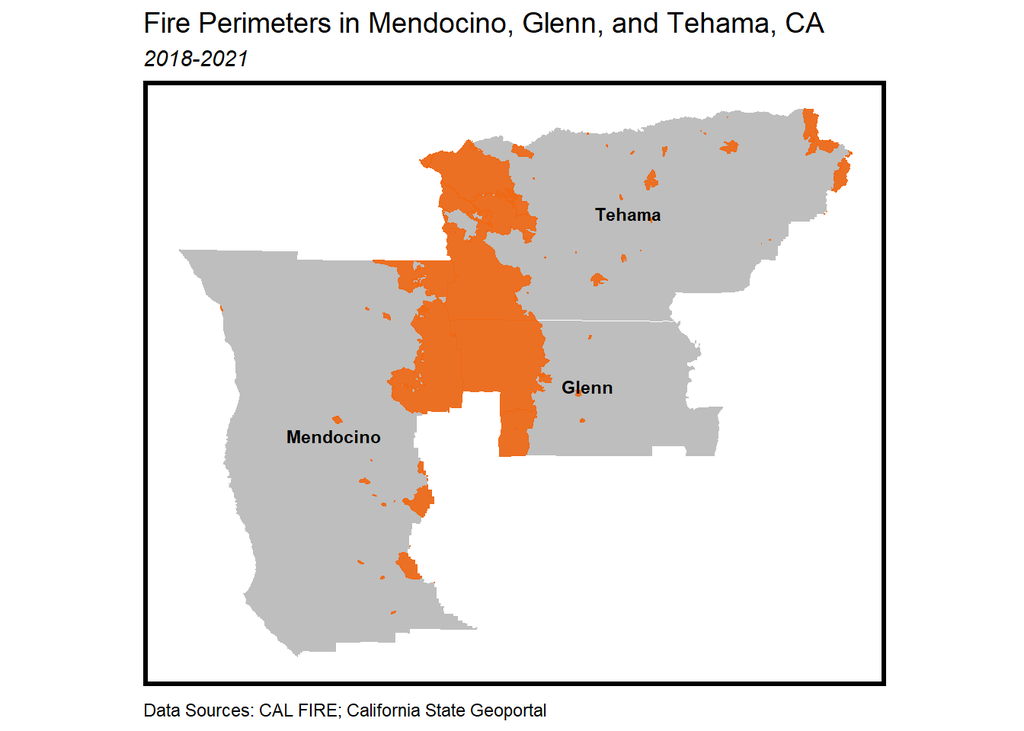

```r
peri1820 <- perimeters %>%
  filter(YEAR_ > 2017)%>%
  st_transform('ESRI:102242')

norcal_only <-
  st_intersection(st_make_valid(norcal2),
                  peri1820)

ggplot()+
  geom_sf(data=norcal2, fill="gray", color="white") +
  geom_sf(data=norcal_only, fill="#f06813", color="#f06813", alpha=0.9) +
     geom_text(data = centroids_counties, aes(X, Y, label = COUNTY_NAME), size = 3, fontface="bold")+
  labs(title = "Fire Perimeters in Mendocino, Glenn, and Tehama, CA",
       subtitle="2018-2021",
       caption="Data Sources: CAL FIRE; California State Geoportal") +
  mapTheme()
```

Then we divided the whole area by fishnet with a size of 2000 meters. Purple means the lowest occurrence, and yellow means the highest occurrence. We also mapped the burned and unburned land as the dependent variable, and as the map shows, the result corresponds to the fire incidence map.

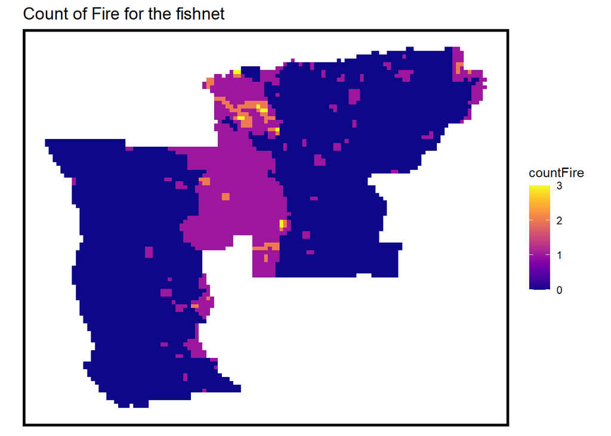

```r
fire_net <-
  dplyr::select(peri1820) %>%
  mutate(countFire = 1) %>%
  aggregate(., fishnet, sum) %>%
  dplyr::mutate(countFire = replace_na(countFire, 0),
         uniqueID = 1:n(),
         cvID = sample(round(nrow(fishnet) / 24),
                       size=nrow(fishnet), replace = TRUE))
fire_net <-
  fire_net %>%
  dplyr::mutate(burned = case_when(countFire == 0 ~ "no",
                                   countFire != 0 ~ "yes"))

ggplot() +
  geom_sf(data = fire_net, aes(fill = countFire), color = NA) +
  scale_fill_viridis(option="C") +
  labs(title = "Count of Fire for the fishnet") +
  mapTheme()+ theme(legend.position='right')
```

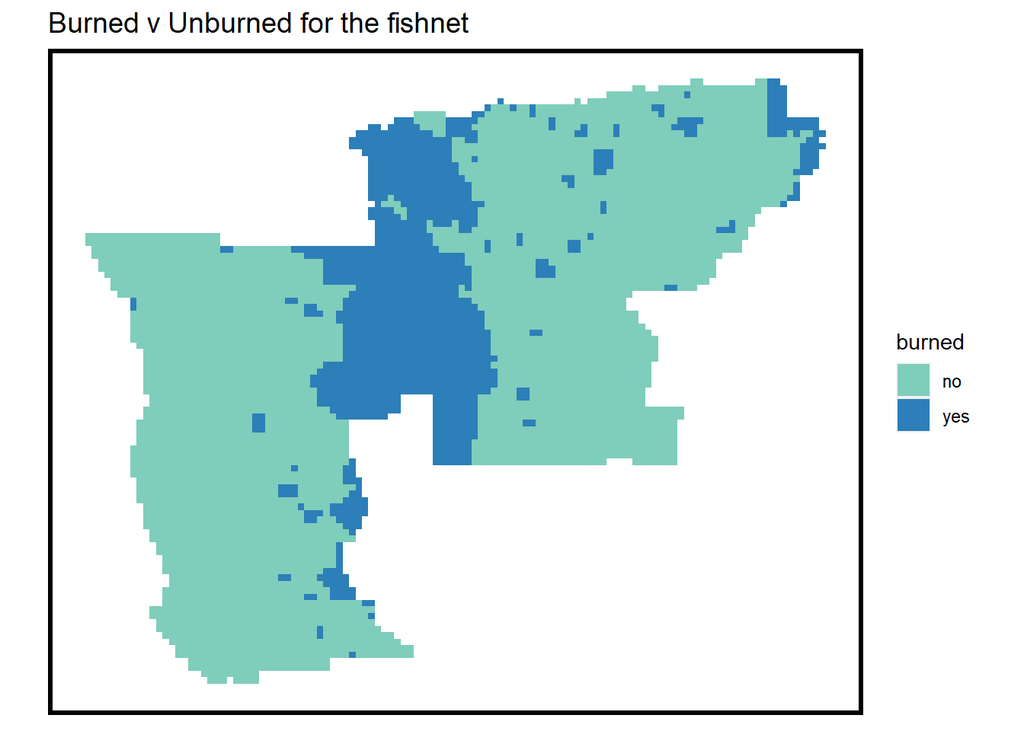

```r
ggplot() +
  geom_sf(data = fire_net, aes(fill = burned), color = NA) +
  labs(title = "Burned v Unburned for the fishnet") +
  scale_fill_manual(values = palette2)+
  mapTheme()
```

To find out the reasons for fires, we then tested with different variables.

### 2.2 Raster Data: Vegetation, Elevation

We explore land cover because we think some kinds of vegetation species may result in higher risk of wildfire. Vegetation is the fuel to wildfires. From the map, we can see that evergreen forests and shrubs made the highest share of land cover among all land cover types, indicating ample fuel for the occurrence of wildfire in this area. We also conducted mode analysis to find which vegetation species made up the highest concentration of vegetation in the area by fishnet.

```r
land_cover <- raster("D:/Teresa/508final/nlcd_2019_land_cover_l48_20210604/nlcd_2019_land_cover_l48_20210604.img")

# #reclass <- c(0,10,0,
#              10,11,11,
#              11,12,12,
#              12,20,0,
#              20,21,21,
#              21,22,22,
#              22,23,23,
#              23,24,24,
#              24,30,0,
#              30,31,31,
#              31,40,0,
#              40,41,41,
#              41,42,42,
#              42,43,43,
#              44,51,0,
#              51,52,52,
#              52,70,0,
#              70,71,71,
#              71,80,0,
#              80,81,81,
#              81,82,82,
#              82,89,0,
#              89,90,90,
#              90,94,0,
#              94,95,95,
#              95,255,0
#              )
# class_matrix <- matrix(reclass, ncol = 3, byrow= TRUE)
#land_cover2 <- reclassify(land_cover, class_matrix)



#lc2 <- crop(y = norcal2 %>% st_transform(crs(land_cover)))
fishnet1 <- cbind(fire_net, exact_extract(land_cover, fishnet %>% st_transform(crs(land_cover)), 'majority'))
fishnet1 <- fishnet1 %>%
  dplyr::rename(landcover = exact_extract.land_cover..fishnet.....st_transform.crs.land_cover....)


elevation <- raster("D:/Teresa/508final/elevation.tif")
#crop(y = norcal2 %>% st_transform(crs(elevation)))
fishnet2 <- cbind(fishnet1, exact_extract(elevation, fishnet %>% st_transform(crs(elevation)), 'mean'))
fishnet2 <- fishnet2 %>%
  dplyr::rename(elevation = exact_extract.elevation..fishnet.....st_transform.crs.elevation....)

fishnet2 <- fishnet2%>%
  dplyr::mutate(land_cover = case_when(landcover == 11 ~ "water",
                                       landcover == 12 ~ "perennial snow",
                                       landcover == 21 ~ "developed, open space",
                                       landcover == 22 ~ "developed, low intensity",
                                       landcover == 23 ~ "developed, median intensity",
                                       landcover == 24 ~ "developed, high intensity",
                                       landcover == 31 ~ "barren",
                                       landcover == 41 ~ "deciduous foreest",
                                       landcover == 42 ~ "evergreen forest",
                                       landcover == 43 ~ "mixed forest",
                                       landcover == 52 ~ "shrub",
                                       landcover == 71 ~ "herbaceous",
                                       landcover == 81 ~ "hay",
                                       landcover == 82 ~ "cultivated crops",
                                       landcover == 90 ~ "woody wetlands",
                                       landcover == 95 ~ "emerging herbaceous wetlands")) %>%
  dplyr::select(-landcover)
```

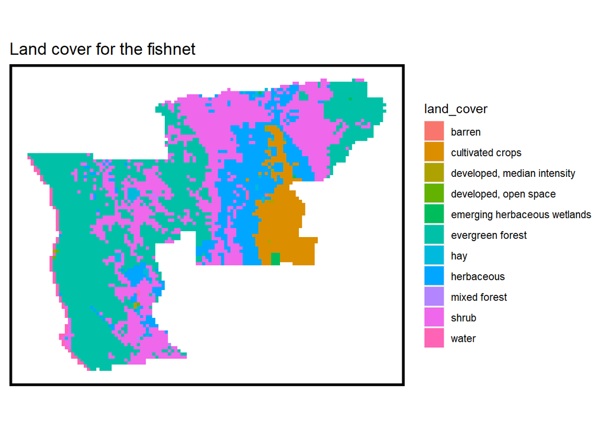

```r
ggplot() +
  geom_sf(data = fishnet2, aes(fill = land_cover), color = NA) +
  labs(title = "Land cover for the fishnet") +
  mapTheme()
```

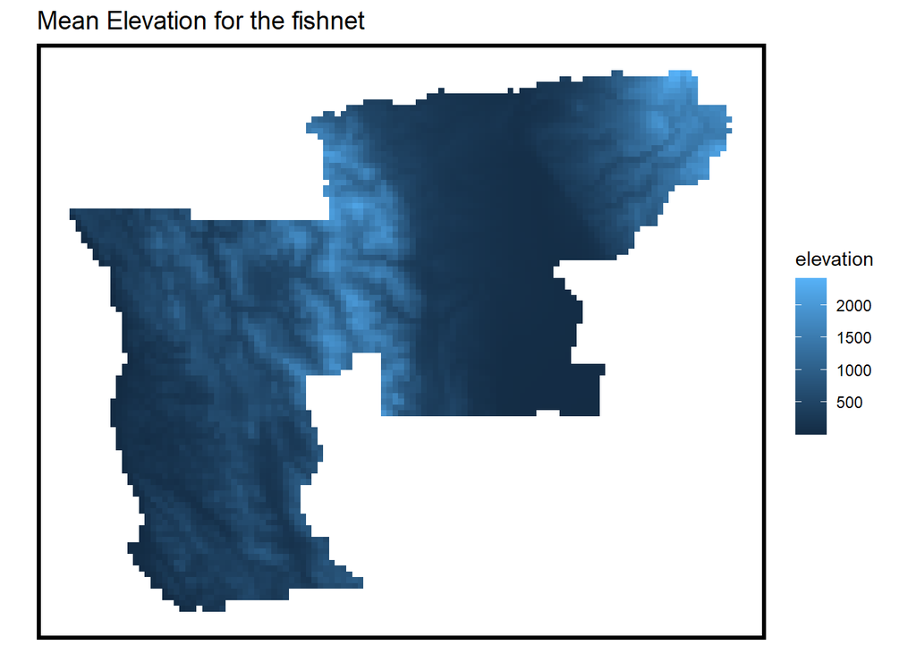

```r
ggplot() +
  geom_sf(data = fishnet2, aes(fill = elevation), color = NA) +
  labs(title = "Mean Elevation for the fishnet") +
  mapTheme()
```

### 2.3 Weather Data

For weather, we gathered the data from ASOS (Automated Surface Observing Systems) weather stations from 2018 to 2021 for Tehama, Glenn, and Mendocino County in California. We found that average temperature is higher and wind speed is faster in the northeastern part of the study area, but the average humidity is higher in Southwestern part. It brings a higher wildfire risk for the northeastern part of the area, because the dryness, faster wind speed, and high temperature are some of the most direct causes of wildfire ignition and spread.

```r
weather <- read.csv("D:/Teresa/508final/weather.csv")

weather_annual <- weather %>% st_as_sf(coords = c("lon", "lat"), crs = 4236, agr="constant") %>% st_transform(st_crs("ESRI:102242"))

library(dplyr)
weather_annual <- weather_annual %>% dplyr::group_by(year, id) %>%
      dplyr::summarize(mean_ann_tmpf = mean(mean_tmpf, na.rm = TRUE),
                       mean_ann_precipitation = mean(mean_precipitation, na.rm = TRUE),
                       mean_ann_humidity = mean(mean_humidity, na.rm = TRUE),
                       mean_ann_windspeed = mean(mean_wind_Speed, na.rm = TRUE))
```

```r
#create new df with only precipitation variable
weather_precip <- weather_annual %>% dplyr::select(geometry, mean_ann_precipitation)
weather_precip.idw <- gstat::idw(mean_ann_precipitation ~ 1, weather_precip, newdata=fishnet2, idp=2.0)
weather_precip.idw <- weather_precip.idw %>% dplyr::rename(avg_precip_idw = var1.pred)
precip.idw <- weather_precip.idw %>% dplyr::select(avg_precip_idw, geometry)
# join to fishnet
fishnet2 <- st_join(fishnet2, precip.idw, join=st_equals)

library(dplyr)
#new df with only wind speed variable
weather_wind <- weather_annual %>% dplyr::select(geometry, mean_ann_windspeed)
weather_wind.idw <- gstat::idw(mean_ann_windspeed ~ 1, weather_wind, newdata=fishnet2, idp=2.0)
weather_wind.idw <- weather_wind.idw %>% dplyr::rename(avg_windspeed_idw = var1.pred)
avg_windspeed.idw <- weather_wind.idw %>% dplyr::select(avg_windspeed_idw, geometry)
# join to fishnet
fishnet2 <- st_join(fishnet2, avg_windspeed.idw, join=st_equals)

weather_temp <- weather_annual %>% dplyr::select(geometry, mean_ann_tmpf)
weather_temp.idw <- gstat::idw(mean_ann_tmpf ~ 1, weather_temp, newdata=fishnet2, idp=2.0)
weather_temp.idw <- weather_temp.idw %>% dplyr::rename(avg_temp_idw = var1.pred)
avg_temp.idw <- weather_temp.idw %>% dplyr::select(avg_temp_idw, geometry)
# join to fishnet
fishnet2 <- st_join(fishnet2, avg_temp.idw, join=st_equals)

library(dplyr)
weather_hum <- weather_annual %>% dplyr::select(geometry, mean_ann_humidity)
weather_hum.idw <- gstat::idw(mean_ann_humidity ~ 1, weather_hum, newdata=fishnet2, idp=2.0)
weather_hum.idw <- weather_hum.idw %>% dplyr::rename(avg_hum_idw = var1.pred)
avg_hum.idw <- weather_hum.idw %>% dplyr::select(avg_hum_idw, geometry)
# join to fishnet
fishnet2 <- st_join(fishnet2, avg_hum.idw, join=st_equals)
```

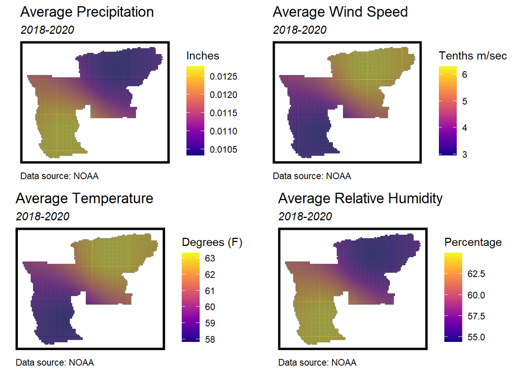

```r
precip <- ggplot()+
  geom_sf(data=weather_precip.idw, aes(fill=avg_precip_idw)) +
  scale_fill_viridis(option="C") +
  labs(title="Average Precipitation",
       subtitle="2018-2020",
       caption="Data source: NOAA",
       fill="Inches")+
          mapTheme() + theme(legend.position='right')

wind <- ggplot()+
  geom_sf(data=weather_wind.idw, aes(fill=avg_windspeed_idw)) +
  scale_fill_viridis(option="C") +
  labs(title="Average Wind Speed",
       subtitle="2018-2020",
       caption="Data source: NOAA",
       fill="Tenths m/sec")+
          mapTheme() + theme(legend.position='right')

temp <- ggplot()+
  geom_sf(data=weather_temp.idw, aes(fill=avg_temp_idw)) +
  scale_fill_viridis(option="C") +
  labs(title="Average Temperature",
       subtitle="2018-2020",
       caption="Data source: NOAA",
       fill="Degrees (F)")+
          mapTheme()+ theme(legend.position='right')

humidity <- ggplot()+
  geom_sf(data=weather_hum.idw, aes(fill=avg_hum_idw)) +
  scale_fill_viridis(option="C") +
  labs(title="Average Relative Humidity",
       subtitle="2018-2020",
       caption="Data source: NOAA",
       fill="Percentage")+
          mapTheme()+ theme(legend.position='right')

grid.arrange(ncol=2, precip, wind, temp, humidity)
```

```r
#burned_num
fishnet2 <-
  fishnet2 %>%
  dplyr::mutate(burned_num = ifelse(countFire == 0, 0, 1))
```

### 2.4 Other Feature Engineering

For Tree mortality, more dead trees mean more fuel for fires to burn. We gathered the data from the California Open Data Portal and the result shows that those dead trees are concentrated in the middle and eastern part of the study area.

```r
tier1hazard_treemortality <- st_read("https://opendata.arcgis.com/datasets/a71a85136b0b414ea734fdfbe3d7674a_0.geojson") %>% st_transform(st_crs(fishnet2))
fishnet2 <- fishnet2 %>% mutate(n_tier1hazard_int = lengths(st_intersects(fishnet2, tier1hazard_treemortality)))
```

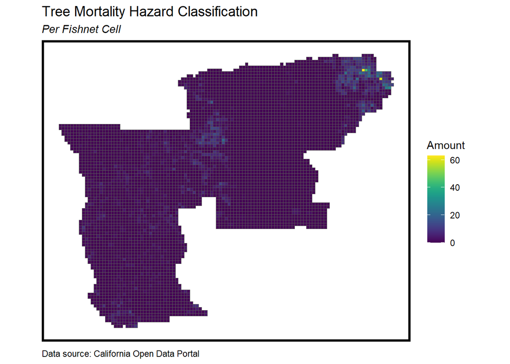

```r
ggplot()+
  geom_sf(data=fishnet2, aes(fill=n_tier1hazard_int)) +
  scale_fill_viridis(option="T") +
  labs(title="Tree Mortality Hazard Classification",
       fill="Amount",
  subtitle="Per Fishnet Cell",
  caption="Data source: California Open Data Portal")+
          mapTheme()
```

We also computed the distance to the nearest campground by using the knn function, because many of the wildfire cases were caused by campfires. Campgrounds are more likely to have campfires. We gathered the data from California Open Data Portal and we found that the campground spread across the study area.

```r
#read in camp grounds
camp_ground <- st_read("D:/Teresa/508final/campground/Campgrounds.shp") %>%
    dplyr::select(geometry) %>%
    st_transform(st_crs(fishnet2))

# calculate distance to nearest camp ground
fishnet2<-
  fishnet2 %>%
    mutate(dist_camp_ground=st_nn(st_centroid(fishnet2), camp_ground, 1))

fishnet2$dist_camp_ground <- as.numeric(fishnet2$dist_camp_ground)
```

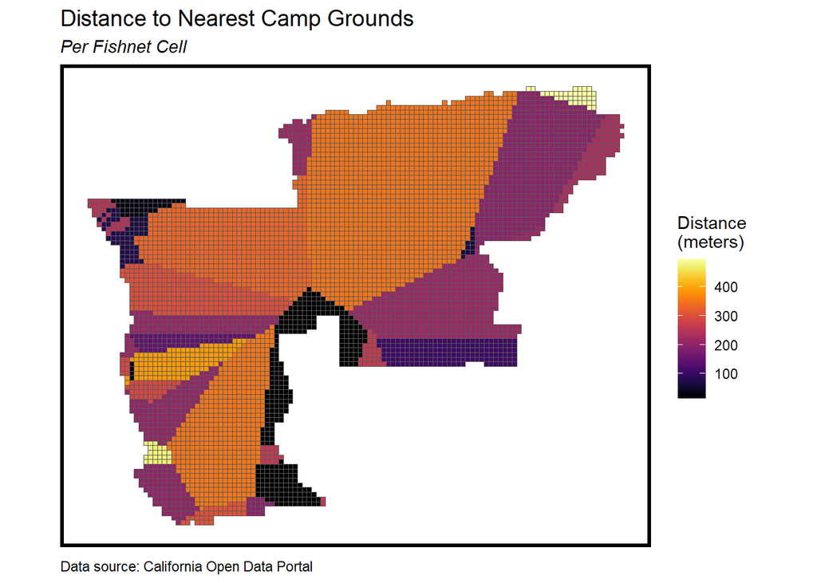

```r
ggplot()+
  geom_sf(data=fishnet2, aes(fill=dist_camp_ground)) +
  scale_fill_viridis(option="B") +
  labs(title="Distance to Nearest Camp Grounds",
       fill="Distance \n(meters)",
  subtitle="Per Fishnet Cell",
  caption="Data source: California Open Data Portal")+
          mapTheme()
```

```r
#read in electric transmission
electric_transmission <- st_read("D:/Teresa/508final/California_Electric_Transmission_Lines.geojson") %>%
    dplyr::select(geometry) %>%
    na.omit() %>%
    st_transform(st_crs(fishnet2))


# calculate distance to nearest electric transmission
fishnet2<-
  fishnet2 %>%
    mutate(dist_elec_tran=st_nn(st_centroid(fishnet2), electric_transmission, 1))

fishnet2$dist_elec_tran <- as.numeric(fishnet2$dist_elec_tran)
```

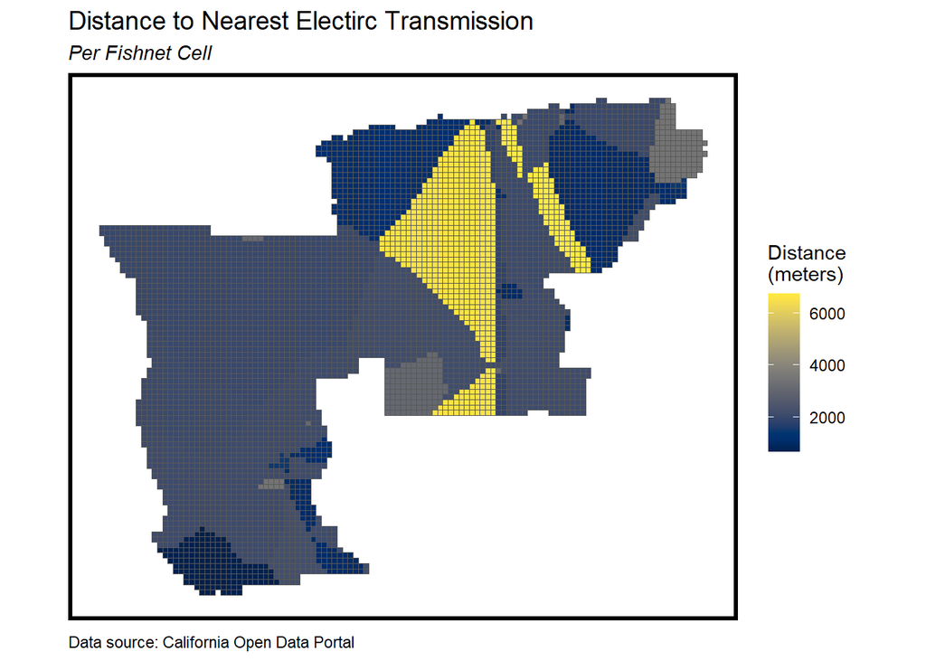

```r
ggplot()+
  geom_sf(data=fishnet2, aes(fill=dist_elec_tran)) +
  scale_fill_viridis(option="E") +
  labs(title="Distance to Nearest Electirc Transmission",
       fill="Distance \n(meters)",
  subtitle="Per Fishnet Cell",
  caption="Data source: California Open Data Portal")+
          mapTheme()
```

```r
#read in electric substations
electric_substations <- st_read("https://opendata.arcgis.com/datasets/7f37f2535d3144e898a53b9385737ee0_0.geojson") %>%
  dplyr::select(Y = Lat, X = Lon) %>%
    na.omit() %>%
    st_as_sf(coords = c("X", "Y"), crs = 4326, agr = "constant") %>%
    st_transform(st_crs(fishnet2))

# calculate distance to nearest electric substation
fishnet2<-
  fishnet2 %>%
    mutate(dist_elec_substation=st_nn(st_centroid(fishnet2), electric_substations, 1))

fishnet2$dist_elec_substation <- as.numeric(fishnet2$dist_elec_substation)
```

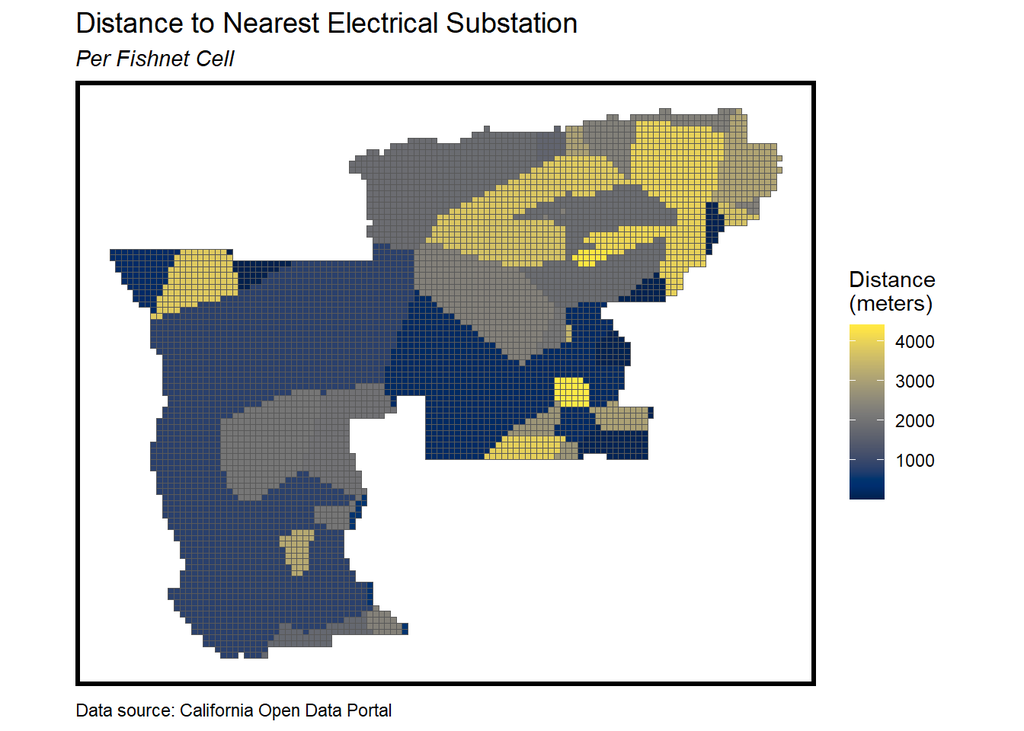

```r
ggplot()+
  geom_sf(data=fishnet2, aes(fill=dist_elec_substation)) +
  scale_fill_viridis(option="E") +
  labs(title="Distance to Nearest Electrical Substation",
       fill="Distance \n(meters)",
  subtitle="Per Fishnet Cell",
  caption="Data source: California Open Data Portal")+
          mapTheme()
```

```r
fire_facilities <- st_read("https://gis.data.cnra.ca.gov/datasets/CALFIRE-Forestry::cal-fire-facilities-for-wildland-fire-protection.geojson?outSR=%7B%22latestWkid%22%3A3857%2C%22wkid%22%3A102100%7D") %>%
  dplyr::select(Y = LAT, X = LON) %>%
    na.omit() %>%
    st_as_sf(coords = c("X", "Y"), crs = 4326, agr = "constant") %>%
  st_zm()%>%
    st_transform(st_crs(fishnet2))


# calculate distance to nearest facility

fishnet2<-
  fishnet2 %>%
    mutate(dist_fire_facilities=st_nn(st_centroid(fishnet2), fire_facilities, 1))

fishnet2$dist_fire_facilities <- as.numeric(fishnet2$dist_fire_facilities)
```

```r
power_plants <- st_read("https://services3.arcgis.com/bWPjFyq029ChCGur/arcgis/rest/services/Power_Plant/FeatureServer/0/query?outFields=*&where=1%3D1&f=geojson") %>%
    dplyr::select(geometry) %>%
    na.omit() %>%
    st_transform(st_crs(fishnet2))



# calculate distance to nearest power plants

fishnet2<-
  fishnet2 %>%
    mutate(dist_power_plants=st_nn(st_centroid(fishnet2), power_plants, 1))

fishnet2$dist_power_plants <- as.numeric(fishnet2$dist_power_plants)
```

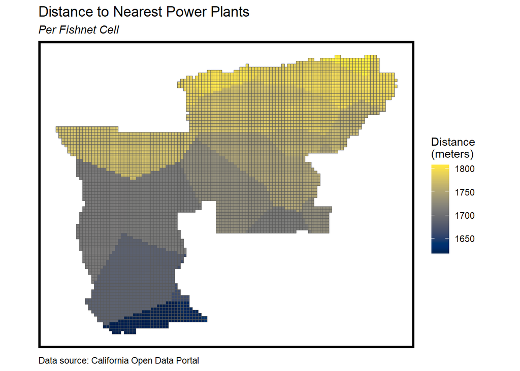

```r
ggplot()+
  geom_sf(data=fishnet2, aes(fill=dist_power_plants)) +
  scale_fill_viridis(option="E") +
  labs(title="Distance to Nearest Power Plants",
       fill="Distance \n(meters)",
  subtitle="Per Fishnet Cell",
  caption="Data source: California Open Data Portal")+
          mapTheme()
```

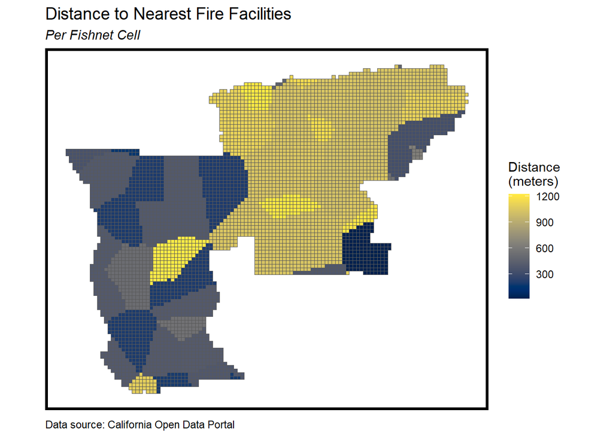

```r
ggplot()+
  geom_sf(data=fishnet2, aes(fill=dist_fire_facilities)) +
  scale_fill_viridis(option="E") +
  labs(title="Distance to Nearest Fire Facilities",
       fill="Distance \n(meters)",
  subtitle="Per Fishnet Cell",
  caption="Data source: California Open Data Portal")+
          mapTheme()
```

```r
#write.csv(fishnet2, "D:/Teresa/508final/fishnet2.csv")
```

## 3. Model

In this section, we use a logistic regression model which can predict a binary outcome, along with the variables and the new features. It is a well-suited model for our case of predicting the probability that a fire will occur. First, the data is divided into 75% of training datasets and 25% of testing datasets, and the model runs on the training set by using createDataPartition. Then, the regression model used all the variables including the engineered features that help improve the model. As a result, the model has the lowest AIC, which shows a better fit.

```r
set.seed(3456)
trainIndex <- createDataPartition(fishnet2$burned,
                                  p = .75,
                                  list = FALSE,
                                  times = 1)
fireTrain <- fishnet2[ trainIndex,]
fireTest  <- fishnet2[-trainIndex,]
```

```r
reg1<- glm(burned_num ~ .,
                  data=st_drop_geometry(fireTrain) %>% dplyr::select(-uniqueID, -burned, -countFire, -cvID, -land_cover, -dist_elec_tran), family="binomial")
summary(reg1)
```

```
##
## Call:
## glm(formula = burned_num ~ ., family = "binomial", data = st_drop_geometry(fireTrain) %>%
##     dplyr::select(-uniqueID, -burned, -countFire, -cvID, -land_cover,
##         -dist_elec_tran))
##
## Deviance Residuals:
##     Min       1Q   Median       3Q      Max
## -3.1772  -0.5114  -0.3179  -0.1380   2.9709
##
## Coefficients: (3 not defined because of singularities)
##                        Estimate Std. Error z value Pr(>|z|)
## (Intercept)           2.457e+01  5.045e+00   4.871 1.11e-06 ***
## elevation             3.635e-03  1.359e-04  26.759  < 2e-16 ***
## avg_precip_idw       -6.639e+02  1.204e+02  -5.515 3.49e-08 ***
## avg_windspeed_idw            NA         NA      NA       NA
## avg_temp_idw                 NA         NA      NA       NA
## avg_hum_idw                  NA         NA      NA       NA
## n_tier1hazard_int    -9.250e-02  2.006e-02  -4.611 4.01e-06 ***
## dist_camp_ground      1.620e-03  5.473e-04   2.960  0.00307 **
## dist_elec_substation -8.112e-04  5.557e-05 -14.599  < 2e-16 ***
## dist_fire_facilities  1.786e-03  1.665e-04  10.728  < 2e-16 ***
## dist_power_plants    -1.218e-02  2.268e-03  -5.371 7.82e-08 ***
## ---
## Signif. codes:  0 '***' 0.001 '**' 0.01 '*' 0.05 '.' 0.1 ' ' 1
##
## (Dispersion parameter for binomial family taken to be 1)
##
##     Null deviance: 4204.5  on 4003  degrees of freedom
## Residual deviance: 2583.2  on 3996  degrees of freedom
## AIC: 2599.2
##
## Number of Fisher Scoring iterations: 6
```

In this section, to ensure the generalizability of the model, which needs to have a great performance on new data and predict accurately, we analyze the goodness of fits. First, using fit metrics, we can observe the McFadden R-Squared, which suggests that the higher, the better. The following calculation shows that the regression model has the best fit. The results of the model for the training data are included below.

```r
pR2(reg1)
```

```
## fitting null model for pseudo-r2
```

```
##           llh       llhNull            G2      McFadden          r2ML
## -1291.5796086 -2102.2721588  1621.3851004     0.3856268     0.3329841
##          r2CU
##     0.5122104
```

### 3.1 Goodness of Fit

```r
testProbs <- data.frame(Outcome = as.factor(fireTest$burned_num),
                        Probs = predict(reg1, fireTest, type= "response"))

testProbs <-
  testProbs %>%
  mutate(predOutcome  = as.factor(ifelse(testProbs$Probs > 0.5 , 1, 0)))
```

#### 3.1.1 Confusion Matrix and Statistics

In this part, I use confusion metrics to better see how the prediction performs. The confusion matrix and its statistics for the regression are shown below. The matrix shows the comparison between observed and predicted burned and unburned area with the fire occurrence is 50% threshold. The accuracy is 88%. Sensitivity, which is the ability to predict true positive outcomes, is 58%. Specificity, which is the ability to predict true negative outcomes, is 96%. This shows that our model can better predict absence of fire and actually no fire occurs. But still, prediction of fire truly occurring is still a moderate prediction in our model.

```r
xtab.reg1 <-caret::confusionMatrix(testProbs$predOutcome, testProbs$Outcome,
                       positive = "1")

as.matrix(xtab.reg1) %>% kable(caption = "Confusion Matrix") %>% kable_styling("striped", full_width = T, font_size = 14, position = "left")
```

Confusion Matrix

|  | 0 | 1 |
| --- | --- | --- |
| 0 | 1004 | 122 |
| 1 | 39 | 169 |

```r
caret::confusionMatrix(testProbs$predOutcome, testProbs$Outcome,
                       positive = "1")
```

```
## Confusion Matrix and Statistics
##
##           Reference
## Prediction    0    1
##          0 1004  122
##          1   39  169
##
##                Accuracy : 0.8793
##                  95% CI : (0.8606, 0.8963)
##     No Information Rate : 0.7819
##     P-Value [Acc > NIR] : < 2.2e-16
##
##                   Kappa : 0.6056
##
##  Mcnemar's Test P-Value : 1.03e-10
##
##             Sensitivity : 0.5808
##             Specificity : 0.9626
##          Pos Pred Value : 0.8125
##          Neg Pred Value : 0.8917
##              Prevalence : 0.2181
##          Detection Rate : 0.1267
##    Detection Prevalence : 0.1559
##       Balanced Accuracy : 0.7717
##
##        'Positive' Class : 1
##
```

```r
as.matrix(xtab.reg1, what="classes") %>% kable(caption = "Confusion Matrix - Statistics") %>% kable_styling(font_size = 14, full_width = T,
                bootstrap_options = c("striped", "hover"))
```

Confusion Matrix - Statistics

| Sensitivity | 0.5807560 |
| --- | --- |
| Specificity | 0.9626079 |
| Pos Pred Value | 0.8125000 |
| Neg Pred Value | 0.8916519 |
| Precision | 0.8125000 |
| Recall | 0.5807560 |
| F1 | 0.6773547 |
| Prevalence | 0.2181409 |
| Detection Rate | 0.1266867 |
| Detection Prevalence | 0.1559220 |
| Balanced Accuracy | 0.7716819 |

#### 3.1.2. Distribution of Predicted Probabilities

Below shows a distribution of outcome of the predicted probabilities in our model. The model can better predict the negatives(no fire occurs) than the positives(fire occurs).

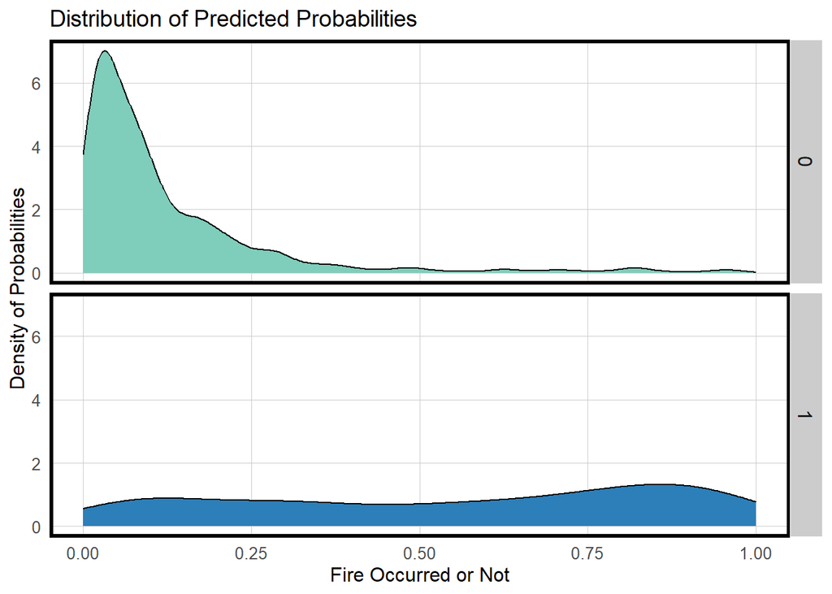

```r
ggplot(testProbs, aes(x = Probs, fill = as.factor(Outcome))) +
  geom_density() +
  facet_grid(Outcome ~ .) +
  scale_fill_manual(values = palette2) + xlim(0, 1) +
  labs(x = "Fire Occurred or Not", y = "Density of Probabilities",
       title = "Distribution of Predicted Probabilities") +
  plotTheme() + theme(strip.text.x = element_text(size = 18),
        legend.position = "none")
```

#### 3.1.3. ROC Curve

By plotting the ROC curve, we can see that if it includes a larger area under the curve, it is a better model. As I plotted below, the model includes an area under the curve by 0.8773, which indicates itself a fairly useful fit. Note that the points on the ROC curve means the model will predict true positive while predicting false positive correctly under the threshold.

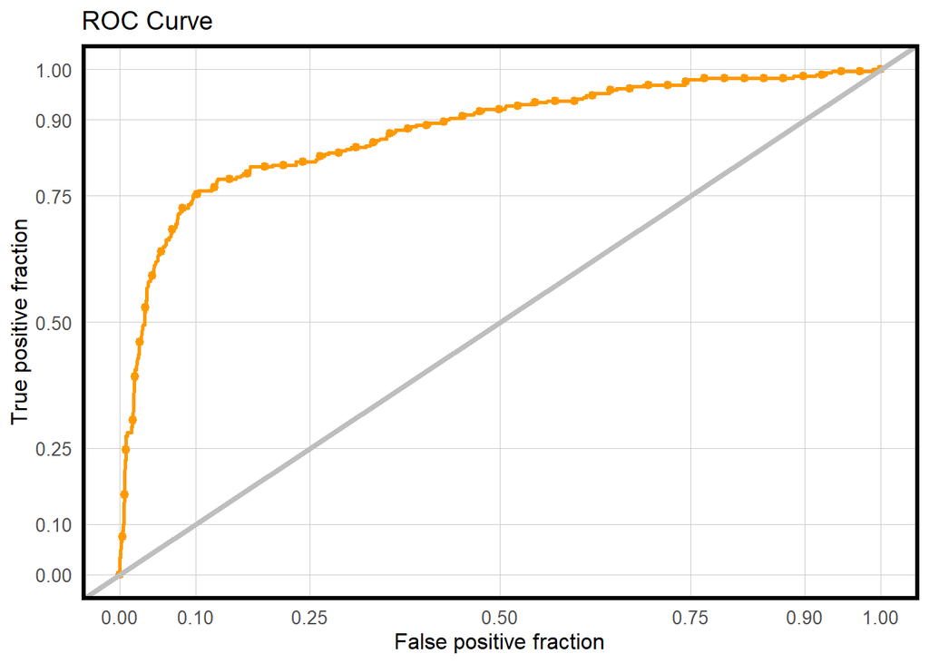

```r
ggplot(testProbs, aes(d = as.numeric(Outcome), m = Probs)) +
  geom_roc(n.cuts = 50, labels = FALSE, colour = "#FE9900") +
  style_roc(theme = theme_grey) +
  geom_abline(slope = 1, intercept = 0, size = 1.5, color = 'grey') +
  labs(title = "ROC Curve") + plotTheme()
```

```r
auc(testProbs$Outcome, testProbs$Probs)
```

```
## Area under the curve: 0.8773
```

### 3.2 Cross Validation

Using cross validation to repeat the process to see the performance of the regression models can ensure that the model generalizes well across contexts. A k-fold cross validation is performed in this section. The model has a ROC of 89% and we can still observe that the model can better predict the true negative.

```r
ctrl <- trainControl(method = "cv", number = 100, classProbs=TRUE, summaryFunction=twoClassSummary)

# str(fishnet2$burned)
# fishnet2$burned <- as.factor(fishnet2$burned)
# fishnet2$burned <- fct_rev(fishnet2$burned)

cvFit2 <- train(burned ~ .,
                  data=st_drop_geometry(fishnet2) %>%
                    dplyr::select(-uniqueID, -burned_num, -countFire, -dist_elec_tran),
                method="glm", family="binomial",
                metric="ROC", trControl = ctrl)

cvFit2
```

#### 3.2.1 Cross Validation Results

Using cross validation shows that our model perform better when predicting negatives thant predicting positive. It is quite fair results since our use case can also benefit from predincting true negative and shows that there will be no fire for users to pass through the area.

```r
print(cvFit2) %>% kable(caption="Cross-Validation Results") %>% kable_styling(font_size = 14, full_width = T,bootstrap_options = c("striped", "hover"))
```

```
## Generalized Linear Model
##
## 5338 samples
##   12 predictor
##    2 classes: 'no', 'yes'
##
## No pre-processing
## Resampling: Cross-Validated (100 fold)
## Summary of sample sizes: 5285, 5284, 5284, 5284, 5285, 5284, ...
## Resampling results:
##
##   ROC        Sens       Spec
##   0.8900086  0.9588444  0.5990909
```

Cross-Validation Results

|  | ROC | Sens | Spec |
| --- | --- | --- | --- |
|  | 0.8900086 | 0.9588444 | 0.5990909 |

The faceted plots below shows cross-validation goodness of fit metrics, which include the mean for area under the curve (“ROC”), sensitivity (“Sens”), and specificity (“Spec”) across all of the 100 folds.(the data in of Sens and Spec are reversed, further fix needed)

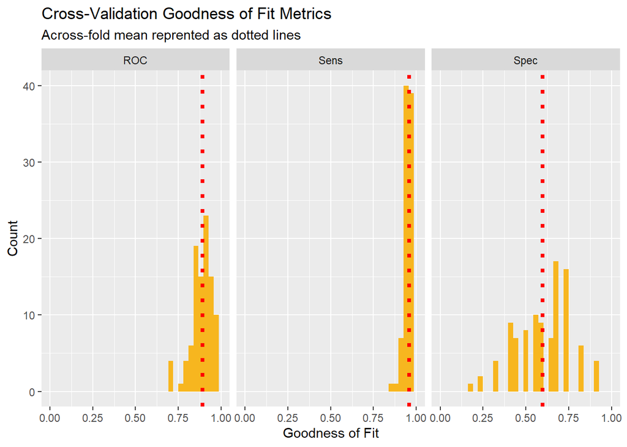

```r
dplyr::select(cvFit2$resample, -Resample) %>%
  gather(metric, value) %>%
  left_join(gather(cvFit2$results[2:4], metric, mean)) %>%
  ggplot(aes(value)) +
    geom_histogram(bins=35, fill = "#f7b61f") +
    facet_wrap(~metric) +
    geom_vline(aes(xintercept = mean), colour = "red", linetype = 3, size = 1.5) +
    scale_x_continuous(limits = c(0, 1)) +
    labs(x="Goodness of Fit", y="Count", title="Cross-Validation Goodness of Fit Metrics",
         subtitle = "Across-fold mean reprented as dotted lines")
```

### 3.3 Costs and Benefits

Our model will not have perfect accuracy, and when determining the optimal threshold it’s important to consider the costs and benefits of inaccurately predicting data. Keep in mind that the ultimate use case for this data is to help inform where the fire occurs and pass through the potentially harmful area to avoid fire. Let’s make some approximations and assume the following: * Google maps earn 4.3 billion every year, and there are 143 million users every month. So, we assume that every user contributes $2.32 in revenue from Google maps. * Predictions are being made at the cell level * User will quit using the app when a prediction is wrong

```r
 # cost_benefit_table <-
 #    testProbs %>%
 #     mutate(predOutcome = ifelse(Probs > x, 1, 0)) %>%
 #       count(predOutcome, Outcome) %>%
 #       summarize(True_Negative = sum(n[predOutcome==0 & Outcome==0]),
 #                 True_Positive = sum(n[predOutcome==1 & Outcome==1]),
 #                 False_Negative = sum(n[predOutcome==0 & Outcome==1]),
 #                 False_Positive = sum(n[predOutcome==1 & Outcome==0])) %>%
 #        gather(Variable, Count) %>%
 #        mutate(Revenue =
 #                ifelse(Variable == "True_Negative", Count * 2.32,
 #                ifelse(Variable == "True_Positive",Count * 2.32,
 #                ifelse(Variable == "False_Negative", Count * 0,
 #                ifelse(Variable == "False_Positive", Count * (-2.32), 0))))) %>%
 #     bind_cols(data.frame(Description = c(
 #               "Predicted correctly fire will not occur and it does not happen. Users keep using the app.",
 #               "Predicted correctly fire will occur and it happens. Users keep using the app.",
 #               "Predicted incorrectly that fire will occur but the fire does not occur. Users might not notice and won’t change the user behavior.",
 #               "Predicted incorrectly that fire will not occur but the fire occurs. Users quit using the app.")))
 #
 # kable(cost_benefit_table,
 #        caption = "Cost/Benefit Table") %>% kable_styling()
```

#### 3.3.1 Optimal Threshold

It is important to identify the threshold that provides the greatest accuracy to best optimize our model for the use. We add up the counts of each prediction and calculate the percentage to define our threshold. The optimal threshold in this case is 0.41, which has the highest accuracy among all.

```r
iterateThresholds <- function(data, group) {
   group <- enquo(group)
  x = .01
  all_prediction <- data.frame()
  while (x <= 1) {

  this_prediction <-
      testProbs %>%
      mutate(predOutcome = ifelse(Probs > x, 1, 0)) %>%
         group_by(!!group) %>%
      dplyr::count(predOutcome, Outcome) %>%
      dplyr::summarize(TN_sum = sum(n[predOutcome==0 & Outcome==0]),
                        TP_sum = sum(n[predOutcome==1 & Outcome==1]),
                        FN_sum = sum(n[predOutcome==0 & Outcome==1]),
                        FP_sum = sum(n[predOutcome==1 & Outcome==0]),
            total=sum(n)) %>%
    mutate(True_Positive = TP_sum / total,
         True_Negative = TN_sum / total,
         False_Negative = FN_sum / total,
         False_Positive = FP_sum / total,
         Accuracy = (TP_sum + TN_sum) / total, Threshold = x)

  all_prediction <- rbind(all_prediction, this_prediction)
  x <- x + .01
  }
return(all_prediction)
}
```

```r
whichThreshold <- iterateThresholds(testProbs)

allThresholds<-kable(whichThreshold) %>%
  kable_styling(bootstrap_options = "striped", full_width = FALSE)%>%
  scroll_box(width = "100%", height = "500px")

allThresholds
```

[output not shown]

[output cut: 69 more lines]

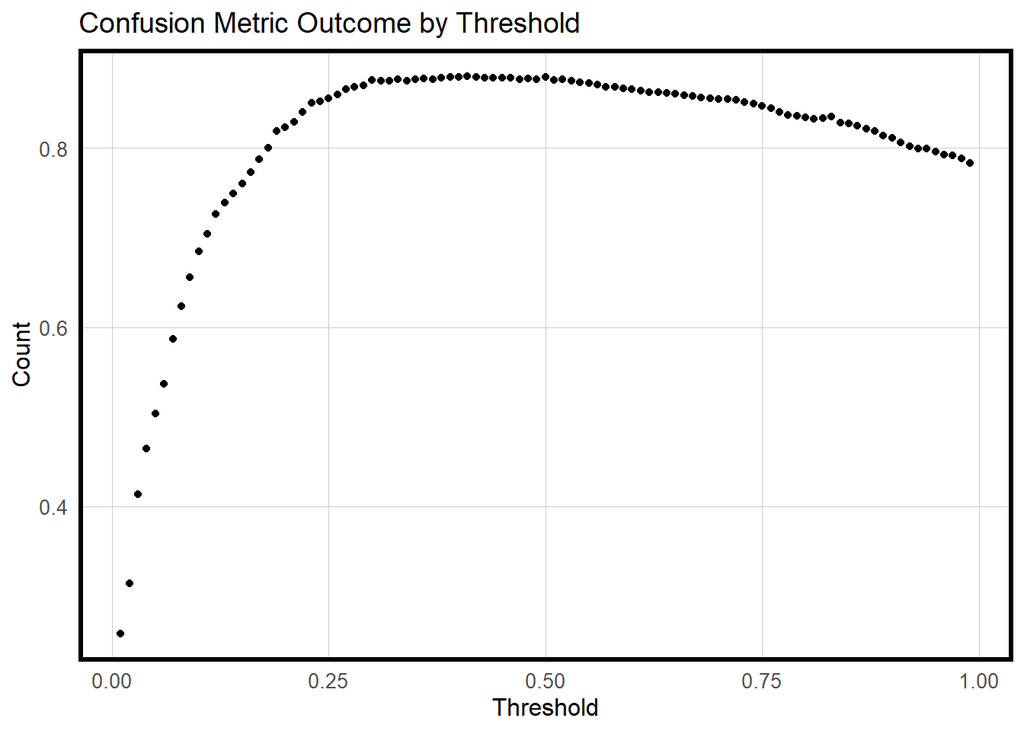

```r
whichThreshold <- iterateThresholds(testProbs)

whichThreshold %>%
  ggplot(.,aes(Threshold, Accuracy)) +
  geom_point() +
  scale_colour_manual(values = paletteInferno5) +
  labs(title = "Confusion Metric Outcome by Threshold",
       y = "Count") +
  guides(colour=guide_legend(title = "Legend")) +
  plotTheme()
```

## 4. Results

We join back the predicted probabilities to the fishnet by the unique ID of each cell. We also use weighting to select the grid cells value when overlapped in joining into census tracts.

```r
predict_fishnet <-
  data.frame(uniqueID = fishnet2$uniqueID,
  Outcome = fishnet2$burned,
  Probs = predict(reg1, fishnet2, type="response"))

predict_fishnet <-
  predict_fishnet %>%
  mutate(predOutcome  = as.factor(ifelse(predict_fishnet$Probs > 0.41, 1, 0)))


fishnet_final_preds <- cbind(fishnet2,predict_fishnet)
```

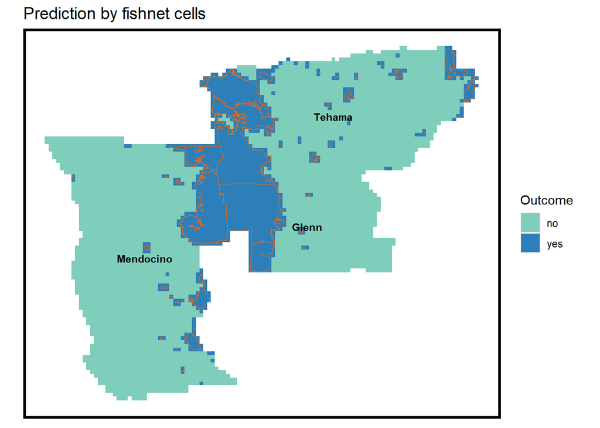

```r
ggplot() +
  geom_sf(data = fishnet_final_preds, aes(fill = Outcome), color = NA) +
  scale_fill_manual(values = palette2)+
  geom_sf(data=norcal_only, fill= NA, color="#f06813", alpha=0.9) +
     geom_text(data = centroids_counties, aes(X, Y, label = COUNTY_NAME), size = 3, fontface="bold")+
  labs(title = "Prediction by fishnet cells") +
  mapTheme()
```

```r
census_api_key("16325a5baedf1c986a182c3321f90022be22845a", overwrite = TRUE)

tracts20 <-
  get_acs(geography = "tract",
          variables = c("B25026_001E"),
          year=2020, state=06, geometry=TRUE) %>%
  st_transform('ESRI:102242')
```

```r
fishnet_final_preds_only <- fishnet_final_preds %>% dplyr::select(uniqueID, Probs, geometry)

interpolate_probs <-
  dplyr::select(fishnet_final_preds, Probs) %>%
  st_interpolate_aw(., tracts20, extensive = FALSE) %>% st_sf()


interpolation_tracts <- st_join(interpolate_probs, tracts20, join=st_equals)

fireProb_tracts <- interpolation_tracts %>% dplyr::select(GEOID, geometry, Probs) %>% st_sf()

fireProb_tracts_nogeom <- interpolation_tracts %>% dplyr::select(GEOID, Probs) %>% st_drop_geometry()
final_norcal_only <-
  st_intersection(st_make_valid(norcal2),
                  fireProb_tracts)
#6. write.csv
```

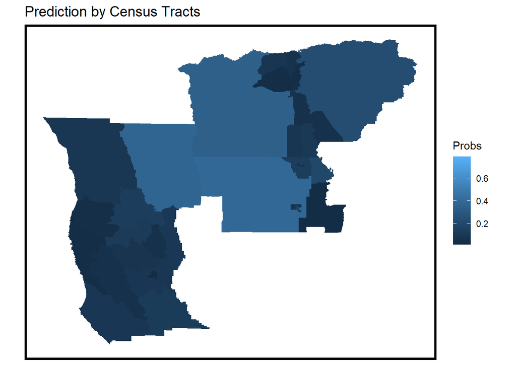

```r
ggplot() +
  geom_sf(data = final_norcal_only, aes(fill = Probs), color = NA) +
  labs(title = "Prediction by Census Tracts") +
  mapTheme()
```

## 5. Discussion

We are excited to use our model to better predict the wildfire occurrence in northern California. We ran our model and as you can see from the results maps, one by fishnet and one by census tract, we predicted that the fires are more likely to happen in the middle part of the study area. By adding this layer into Google maps, users can avoid the fire occurring areas and find an optimized route to arrive at their destination more effectively and safely. In this model, we only predict the location of wildfires. Since we want to predict the wildfire risk by day, our model will update and run itself everyday with the changing historic or time data. For example, if we want to predict the wildfire risk for Dec. 30th, 2021, the model will use the wildfire history and weather data from Jan. 2nd to 2018 to Dec. 29, 2021. If we want to predict Dec. 30th, 2021, the model will use the wildfire history and weather data from Jan. 3rd, 2018 to Dec. 30th , 2021.

For our next step, we are going to develop the application with Google and work on the time lag variables. Adding more time features to improve our model to predict more accurate prediction by time. In the long term, we will perform user testing and keep refining our model, and if our model works for the selected counties, we may promote this model to a larger geographic area. Also, we will develop customer services to collect fire data that can help us better predict the fire occurrence and improve our prediction in positive incidents, which may cause more harm when users pass the areas without any notice.